# Geog533 Lab 7 - Correlation

Nana Ama Obeng Nti

## Question 1

This is Exercise 1 in Chapter 7 of the Textbook [R].

### Problem 1a

Find the correlation coefficient, *r*, for the following sample data on income and education:

```r
library(knitr)
obs <- seq(1:5)
income <- c(30,28,52,40,35)
edu <- c(12,13,18,16,17)
df <- data.frame(obs,income,edu)
names(df) <- c("Observation","Income ($*1000)","Education (Years)")
kable(df)
```

| Observation | Income ($*1000) | Education (Years) |
| --- | --- | --- |
| 1 | 30 | 12 |
| 2 | 28 | 13 |
| 3 | 52 | 18 |
| 4 | 40 | 16 |
| 5 | 35 | 17 |

Solution 1a

```r
r <- cor(df$`Income ($*1000)`, df$`Education (Years)`)
r
```

```
[1] 0.83577
```

### Problem 1b

Test the null hypothesis ρ = 0.

Solution 1b

```r
r <- cor.test(df$`Income ($*1000)`, df$`Education (Years)`)
r
```

```
    Pearson's product-moment correlation

data:  df$`Income ($*1000)` and df$`Education (Years)`
t = 2.6364, df = 3, p-value = 0.0779
alternative hypothesis: true correlation is not equal to 0
95 percent confidence interval:
 -0.1770427  0.9888709
sample estimates:
    cor
0.83577
```

```r
if(r$p.value>0.05) {
  print("We cannot reject the null hypothesis.")
} else {
  print("We reject the null hypothesis.")
}
```

```
[1] "We cannot reject the null hypothesis."
```

```r
print("We cannot reject the null hypothesis that the true correlation is equal to zero because the p.value is greater than 0.05")
```

```
[1] "We cannot reject the null hypothesis that the true correlation is equal to zero because the p.value is greater than 0.05"
```

### Problem 1c

Find Spearman’s rank correlation coefficient for these data.

Solution 1c

```r
cor <- cor(df$`Income ($*1000)`, df$`Education (Years)`, method = "spearman")
cor
```

```
[1] 0.8
```

### Problem 1d

Test whether the observed value of rs from part (c) is significantly different from zero.

Solution 1d

```r
cor <- cor.test(df$`Income ($*1000)`, df$`Education (Years)`, method = "spearman")
cor
```

```
    Spearman's rank correlation rho

data:  df$`Income ($*1000)` and df$`Education (Years)`
S = 4, p-value = 0.1333
alternative hypothesis: true rho is not equal to 0
sample estimates:
rho
0.8
```

```r
if(cor$p.value>0.05) {
  print("We cannot reject the null hypothesis.")
} else {
  print("We reject the null hypothesis.")
}
```

```
[1] "We cannot reject the null hypothesis."
```

```r
print("We cannot reject the null hypothesis that the true correlation is equal to zero because the p.value is greater than 0.05")
```

```
[1] "We cannot reject the null hypothesis that the true correlation is equal to zero because the p.value is greater than 0.05"
```

## Question 2

This is Exercise 3 in Chapter 7 of the Textbook [R].

### Problem

The distribution of the t-statistic for testing the significance of a correlation coefficient has n – 2 degrees of freedom. If the sample size is 36 and α = 0.05, what is the smallest absolute value a correlation coefficient must have to be significant? What if the sample size is 80?

### Solution.a

```r
##SAMPLE SIZE IS 36
n <- 36
r.crit <- 2/sqrt(n)
r.crit
```

```
[1] 0.3333333
```

```r
print("When the sample size is 36, the smallest absolute value a correlation coefficient must have to be significant is 0.333333")
```

```
[1] "When the sample size is 36, the smallest absolute value a correlation coefficient must have to be significant is 0.333333"
```

### Solution.b

```r
#SAMPLE SIZE IS 80
n <- 80
r.crit <- 2/sqrt(n)
r.crit
```

```
[1] 0.2236068
```

```r
print("When the sample size is 80, the smallest absolute value a correlation coefficient must have to be significant is 0.2236068")
```

```
[1] "When the sample size is 80, the smallest absolute value a correlation coefficient must have to be significant is 0.2236068"
```

## Question 3

This is Exercise 4 in Chapter 7 of the Textbook [R].

### Problem

Find the correlation coefficient for the following data:

```r
library(knitr)
Obs <- seq(1:4)
X <- c(2,8,9,7)
Y <- c(6,6,10,4)
df <- data.frame(Obs,X,Y)
kable(df)
```

| Obs | X | Y |
| --- | --- | --- |
| 1 | 2 | 6 |
| 2 | 8 | 6 |
| 3 | 9 | 10 |
| 4 | 7 | 4 |

### Solution

```r
r.3 <- cor.test(df$X,df$Y,method = "pearson")
r.3
```

```
    Pearson's product-moment correlation

data:  df$X and df$Y
t = 0.5871, df = 2, p-value = 0.6166
alternative hypothesis: true correlation is not equal to 0
95 percent confidence interval:
 -0.9147553  0.9824674
sample estimates:
      cor
0.3834129
```

```r
if(r.3$p.value>0.05){
  print("We cannot reject the null hypothesis")
}else{
  print("We reject the null hypothesis")
}
```

```
[1] "We cannot reject the null hypothesis"
```

```r
print("We cannot reject the null hypothesis that the true correlation is equal to zero because the p.value is greater than 0.05")
```

```
[1] "We cannot reject the null hypothesis that the true correlation is equal to zero because the p.value is greater than 0.05"
```

## Question 4

This is Exercise 6 in Chapter 7 of the Textbook [R].

### Problem

Find the correlation coefficient between median annual income in the United States and the number of horse races won by the leading jockey, for the period 1984–1995. Test the hypothesis that the true correlation coefficient is equal to zero. Interpret your results.

```r
year <- 1984:1994
income <- c(35165,35778,37027,37256,37512,37997,37343,36054,35593,35241,35486)
races <- c(399,469,429,450,474,598,364,430,433,410,317)
df <- data.frame(year,income,races)
names(df) <- c("Year","Median income","Number of races won by leading jockey")
kable(df)
```

| Year | Median income | Number of races won by leading jockey |
| --- | --- | --- |
| 1984 | 35165 | 399 |
| 1985 | 35778 | 469 |
| 1986 | 37027 | 429 |
| 1987 | 37256 | 450 |
| 1988 | 37512 | 474 |
| 1989 | 37997 | 598 |
| 1990 | 37343 | 364 |
| 1991 | 36054 | 430 |
| 1992 | 35593 | 433 |
| 1993 | 35241 | 410 |
| 1994 | 35486 | 317 |

### Solution

```r
r.4 <- cor.test(df$`Median income`,df$`Number of races won by leading jockey`)
r.4
```

```
    Pearson's product-moment correlation

data:  df$`Median income` and df$`Number of races won by leading jockey`
t = 2.0189, df = 9, p-value = 0.07425
alternative hypothesis: true correlation is not equal to 0
95 percent confidence interval:
 -0.06248153  0.86761233
sample estimates:
      cor
0.5583199
```

```r
if(r.4$p.value>0.05){
  print("We cannot reject the null hypothesis")
}else{
  print("We reject the null hypothesis")
}
```

```
[1] "We cannot reject the null hypothesis"
```

```r
print("We cannot reject the null hypothesis that the true correlation is equal to zero because the p.value is greater than 0.05")
```

```
[1] "We cannot reject the null hypothesis that the true correlation is equal to zero because the p.value is greater than 0.05"
```

```r
##INTERPRET YOUR RESULTS
n <- 11
r.crit <- 2/sqrt(n)
r.crit
```

```
[1] 0.6030227
```

```r
print("Eventhough the null hypothesis is accepted, the correlation coefficient of 0.558 is not significant. This is because, a sample size of 11 must have a correlation coefficient of at least 0.603 to be considered significant.")
```

```
[1] "Eventhough the null hypothesis is accepted, the correlation coefficient of 0.558 is not significant. This is because, a sample size of 11 must have a correlation coefficient of at least 0.603 to be considered significant."
```

## Question 5

This is Exercise 7 in Chapter 7 of the Textbook [R].

### Problem

For the following ranked data, find Spearman’s r, and then test the null hypothesis (using a Type I error probability of 0.10) that the true correlation is equal to zero.

```r
library(knitr)
obs <- 1:6
x <- c(1,2,5,6,11,12)
y <- c(8,4,12,3,10,7)
df <- data.frame(obs,x,y)
names(df) <- c("Observation","Rank of x","Rank of y")
kable(df)
```

| Observation | Rank of x | Rank of y |
| --- | --- | --- |
| 1 | 1 | 8 |
| 2 | 2 | 4 |
| 3 | 5 | 12 |
| 4 | 6 | 3 |
| 5 | 11 | 10 |
| 6 | 12 | 7 |

### Solution

```r
r.5 <- cor.test(df$`Rank of x`,df$`Rank of y`,method = "spearman",conf.level = 0.90)
r.5
```

```
    Spearman's rank correlation rho

data:  df$`Rank of x` and df$`Rank of y`
S = 36, p-value = 1
alternative hypothesis: true rho is not equal to 0
sample estimates:
        rho
-0.02857143
```

```r
if(r.5$p.value>0.1){
  print("We cannot reject the null hypothesis")
}else{
  print("We reject the null hypothesis")
}
```

```
[1] "We cannot reject the null hypothesis"
```

```r
print("We cannot reject the null hypothesis that the true correlation is equal to zero because the p.value is greater than 0.05")
```

```
[1] "We cannot reject the null hypothesis that the true correlation is equal to zero because the p.value is greater than 0.05"
```

## Question 6

This is Exercise 8 in Chapter 7 of the Textbook [R].

### Problem

Find Pearson’s r for the following data, and then test the null hypothesis that the correlation coefficient is equal to zero. Use a Type I error probability of 0.05.

```r
library(knitr)
obs <- 1:6
x <- c(3.2,2.4,1.6,8.3,7.2,5.1)
y <- c(6.2,7.3,8.1,2.6,6.3,4.3)
df <- data.frame(obs,x,y)
names(df) <- c("Observation","x","y")
kable(df)
```

| Observation | x | y |
| --- | --- | --- |
| 1 | 3.2 | 6.2 |
| 2 | 2.4 | 7.3 |
| 3 | 1.6 | 8.1 |
| 4 | 8.3 | 2.6 |
| 5 | 7.2 | 6.3 |
| 6 | 5.1 | 4.3 |

### Solution

```r
r.6 <- cor.test(df$x,df$y,method = "pearson")
r.6
```

```
    Pearson's product-moment correlation

data:  df$x and df$y
t = -2.7364, df = 4, p-value = 0.0521
alternative hypothesis: true correlation is not equal to 0
95 percent confidence interval:
 -0.97806755  0.01221668
sample estimates:
       cor
-0.8073491
```

```r
if(r.6$p.value>0.05){
  print("We cannot reject the null hypothesis")
}else{
  print("We reject the null hypothesis")
}
```

```
[1] "We cannot reject the null hypothesis"
```

```r
print("We cannot reject the null hypothesis that the true correlation is equal to zero because the p.value is greater than 0.05")
```

```
[1] "We cannot reject the null hypothesis that the true correlation is equal to zero because the p.value is greater than 0.05"
```

## Question 7

This is Exercise 9 in Chapter 7 of the Textbook [R].

### Problem

Using R and the Milwaukee dataset, find the correlation between number of bedrooms and lot size.

### Solution

```r
df <- read.csv("Milwaukee_Sales.csv",header = T)
df
```

| Stories | FinSqft | Bedrms | Baths | LotSize | SaleDate | SalePrice | Ald | Age | FullBase | Attic | FIREPLACE | AIR_CONDITIONING | Garage | X | Y |
| --- | --- | --- | --- | --- | --- | --- | --- | --- | --- | --- | --- | --- | --- | --- | --- |
| 1.0 | 1560 | 4 | 1.5 | 4680 | 2012-04 | 61000 | 1 | 76 | 1 | 1 | 0 | 0 | 1 | 2551960 | 405664.0 |
| 1.0 | 1538 | 3 | 1.5 | 7100 | 2012-06 | 85900 | 1 | 65 | 1 | 1 | 1 | 1 | 1 | 2543593 | 416385.2 |
| 1.0 | 1359 | 3 | 1.0 | 5040 | 2012-07 | 87500 | 1 | 72 | 0 | 1 | 0 | 1 | 1 | 2553561 | 412893.6 |
| 1.0 | 1339 | 3 | 2.5 | 5000 | 2012-03 | 89900 | 1 | 70 | 1 | 1 | 0 | 1 | 1 | 2551449 | 408569.1 |
| 1.0 | 1213 | 3 | 1.0 | 5125 | 2012-09 | 64500 | 1 | 61 | 1 | 1 | 0 | 1 | 1 | 2541430 | 412143.4 |
| 1.0 | 1206 | 3 | 1.0 | 5880 | 2012-01 | 35000 | 1 | 72 | 1 | 1 | 0 | 1 | 1 | 2547222 | 412509.6 |
| 1.0 | 1062 | 3 | 1.5 | 7560 | 2012-04 | 74700 | 1 | 71 | 1 | 1 | 0 | 0 | 1 | 2552115 | 410277.9 |
| 1.0 | 1033 | 3 | 1.0 | 5320 | 2012-04 | 71000 | 1 | 67 | 1 | 1 | 0 | 0 | 1 | 2552460 | 404941.9 |
| 2.0 | 1664 | 3 | 2.5 | 7800 | 2012-10 | 127500 | 1 | 63 | 1 | 0 | 1 | 1 | 1 | 2553976 | 414520.8 |
| 2.0 | 1237 | 4 | 1.5 | 5542 | 2012-02 | 73027 | 1 | 42 | 1 | 0 | 0 | 0 | 1 | 2549400 | 405251.3 |

[output cut: 990 more lines]

```r
r.7 <- cor.test(df$Bedrms,df$LotSize)
r.7
```

```
    Pearson's product-moment correlation

data:  df$Bedrms and df$LotSize
t = -0.18056, df = 1447, p-value = 0.8567
alternative hypothesis: true correlation is not equal to 0
95 percent confidence interval:
 -0.05622965  0.04676148
sample estimates:
         cor
-0.004746671
```

```r
if(r.7$p.value>0.05){
  print("We cannot reject the null hypothesis")
}else{
  print("We reject the null hypothesis")
}
```

```
[1] "We cannot reject the null hypothesis"
```

```r
print("We cannot reject the null hypothesis that the true correlation is equal to zero because the p.value is greater than 0.05")
```

```
[1] "We cannot reject the null hypothesis that the true correlation is equal to zero because the p.value is greater than 0.05"
```

## Question 8

This is Exercise 10 in Chapter 7 of the Textbook [R].

### Problem

Using R and the Hypothetical UK Housing Prices dataset, find the correlation between floor area and number of bedrooms.

### Solution

```r
df <- read.csv("UK_Housing.csv",header = T)
df
```

| region | price | garage | bedrooms | bathrooms | datebuilt | floorarea | detached | fireplace | agelessthan15 | age65andover | nonwhite | unemploy | ownocc | carsperhh | manuf |
| --- | --- | --- | --- | --- | --- | --- | --- | --- | --- | --- | --- | --- | --- | --- | --- |
| 6 | 25500 | 0 | 3 | 2 | 1973 | 70.4 | 0 | 0 | 26.86 | 8.50 | 0.038 | 11.38 | 52.706 | 0.583 | 23.273 |
| 6 | 17450 | 0 | 1 | 1 | 1982 | 40.9 | 0 | 0 | 23.22 | 16.74 | 1.836 | 11.73 | 60.440 | 0.402 | 11.524 |
| 6 | 22450 | 0 | 2 | 1 | 1883 | 78.6 | 0 | 1 | 20.41 | 15.79 | 0.153 | 5.18 | 59.692 | 0.952 | 12.325 |
| 1 | 22500 | 0 | 2 | 1 | 1912 | 81.9 | 0 | 0 | 19.53 | 15.82 | 2.881 | 4.84 | 59.046 | 0.745 | 12.618 |
| 5 | 53500 | 0 | 3 | 1 | 1959 | 83.9 | 0 | 0 | 19.69 | 18.55 | 0.626 | 8.08 | 57.439 | 0.587 | 12.593 |
| 6 | 48100 | 1 | 2 | 1 | 1952 | 104.8 | 0 | 0 | 18.18 | 19.69 | 1.012 | 0.96 | 61.262 | 0.849 | 7.251 |
| 1 | 29250 | 0 | 3 | 1 | 1894 | 136.8 | 0 | 0 | 24.88 | 17.21 | 1.653 | 12.40 | 59.455 | 0.178 | 19.546 |
| 1 | 35450 | 1 | 3 | 1 | 1975 | 65.3 | 0 | 0 | 21.82 | 16.26 | 1.102 | 3.46 | 53.283 | 0.501 | 12.353 |
| 6 | 21500 | 0 | 2 | 2 | 1910 | 95.6 | 0 | 0 | 21.61 | 18.59 | 0.302 | 9.18 | 58.230 | 0.772 | 16.160 |
| 6 | 28250 | 0 | 1 | 1 | 1900 | 76.8 | 0 | 0 | 23.66 | 15.52 | 3.506 | 11.16 | 51.821 | 0.277 | 11.491 |

[output cut: 489 more lines]

```r
r.8 <- cor.test(df$floorarea,df$bedrooms)
r.8
```

```
    Pearson's product-moment correlation

data:  df$floorarea and df$bedrooms
t = 17.228, df = 497, p-value < 2.2e-16
alternative hypothesis: true correlation is not equal to 0
95 percent confidence interval:
 0.5533890 0.6636246
sample estimates:
      cor
0.6114652
```

```r
if(r.8$p.value>0.05){
  print("We cannot reject the null hypothesis")
}else{
  print("We reject the null hypothesis")
}
```

```
[1] "We reject the null hypothesis"
```

```r
print("We reject the null hypothesis that the true correlation is equal to zero because the p.value is less than 0.05")
```

```
[1] "We reject the null hypothesis that the true correlation is equal to zero because the p.value is less than 0.05"
```

## Question 9

Use the **cars** data frame in the **datasets** package to perform the following tasks:

### Problem 9a

Plot a scatterplot for the data frame (x: speed, y: dist)

Solution 9a

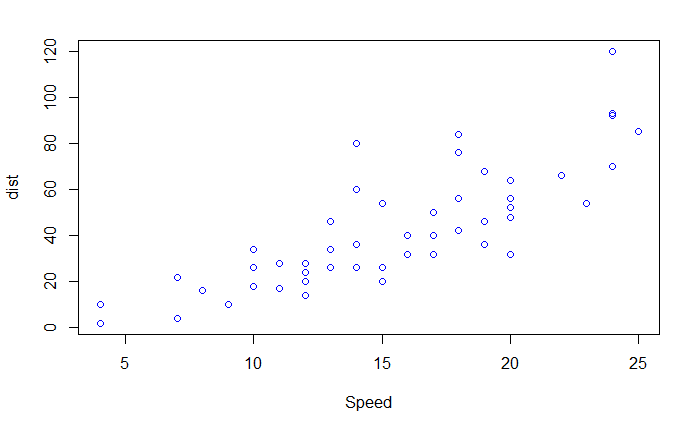

```r
library(datasets)
df <- cars
plot(df,xlab="Speed",ylab="dist",col="blue")
```

### Problem 9b

How many rows in the data frame?

Solution 9b

```r
n <- nrow(df)
n
```

```
[1] 50
```

### Problem 9c

Calculate Pearson’s correlation coefficient using the equation below:
$$r=\frac{\sum_{n}^{i=1}(x_i-\bar{x})(y_i-\bar{y})}{(n-1)s_{x}s_{y}}$$

Solution 9c

```r
library(datasets)
df <- cars
speed <- df$speed
spd.mn<- mean(speed)
spd.mn
```

```
[1] 15.4
```

```r
dist <- df$dist
dis.mn <- mean(dist)
dis.mn
```

```
[1] 42.98
```

```r
sd1 <- sd(speed)
sd1
```

```
[1] 5.287644
```

```r
sd2 <- sd(dist)
sd <- sd1 * sd2
sd
```

```
[1] 136.2593
```

```r
n <- 50
n1 <- n - 1
n1
```

```
[1] 49
```

```r
num <- sum((speed - spd.mn)*(dist - dis.mn))
num
```

```
[1] 5387.4
```

```r
deno <-  n1 * sd
deno
```

```
[1] 6676.706
```

```r
r <- num / deno
r
```

```
[1] 0.8068949
```

```r
t <- r * sqrt (n - 2) / sqrt(1-r^2)
t
```

```
[1] 9.46399
```

```r
t.crit <- qt(0.975, df = n-2)
t.crit
```

```
[1] 2.010635
```

```r
print("We reject the null hypothesis that the true correlation is equal to zero, since the observed value of t (9.46) is greater than the critical value of 2.01")
```

```
[1] "We reject the null hypothesis that the true correlation is equal to zero, since the observed value of t (9.46) is greater than the critical value of 2.01"
```

### Problem 9d

Use the cor.test() function to find Pearson’s correlation coefficient and compare it to the one from part (c)

Solution 9d

```r
r <- cor(df$speed, df$dist, method = "pearson")
r
```

```
[1] 0.8068949
```

```r
result <- cor.test(df$speed,df$dist, method = "pearson")
result
```

```
    Pearson's product-moment correlation

data:  df$speed and df$dist
t = 9.464, df = 48, p-value = 1.49e-12
alternative hypothesis: true correlation is not equal to 0
95 percent confidence interval:
 0.6816422 0.8862036
sample estimates:
      cor
0.8068949
```

```r
if(result$p.value>0.05){
  print("We cannot reject the null hypothesis")
}else{
  print("We reject the null hypothesis")
}
```

```
[1] "We reject the null hypothesis"
```

```r
print("We reject the null hypothesis that the true correlation is equal to zero because the p.value is less than 0.05")
```

```
[1] "We reject the null hypothesis that the true correlation is equal to zero because the p.value is less than 0.05"
```

```r
print("9d and 9c produce the same correlation coefficient output")
```

```
[1] "9d and 9c produce the same correlation coefficient output"
```

### Problem 9e

Calculate Spearman’s rank correlation coefficient using the equation below:
$$r_{S} = 1 - \frac{6\sum_{i=1}^{n}d_{i}^{2}}{n^3-n}$$

Solution 9e

```r
library(datasets)
df <- cars
df
```

| speed | dist |
| --- | --- |
| 4 | 2 |
| 4 | 10 |
| 7 | 4 |
| 7 | 22 |
| 8 | 16 |
| 9 | 10 |
| 10 | 18 |
| 10 | 26 |
| 10 | 34 |
| 11 | 17 |

[output cut: 40 more lines]

```r
n <- nrow(df)
df$rank.sp <- rank(df$speed)
df$rank.ds <- rank(df$dist)
df$d <- df$rank.sp - df$rank.ds
df$d2 <- df$d^2
sum.d2 <- sum(df$d2)
sum.d2
```

```
[1] 3523
```

```r
num <- 6 * sum.d2
num
```

```
[1] 21138
```

```r
deno <- n^3 - n
deno
```

```
[1] 124950
```

```r
x <- num / deno
x
```

```
[1] 0.1691717
```

```r
rs <- 1 - x
rs
```

```
[1] 0.8308283
```

### Problem 9f

Use the cor.test() function to find Spearman’s rank correlation coefficient and compare it to the one from part (e)

Solution 9f

```r
rs <- cor(df$speed, df$dist, method = "spearman")
rs
```

```
[1] 0.8303568
```

```r
result1 <- cor.test(df$speed,df$dist, method = "spearman")
```

```
Cannot compute exact p-value with ties
```

```r
result1
```

```
    Spearman's rank correlation rho

data:  df$speed and df$dist
S = 3532.8, p-value = 8.825e-14
alternative hypothesis: true rho is not equal to 0
sample estimates:
      rho
0.8303568
```

```r
if(result1$p.value>0.05){
  print("We cannot reject the null hypothesis")
}else{
  print("We reject the null hypothesis")
}
```

```
[1] "We reject the null hypothesis"
```

```r
print("We reject the null hypothesis that the true correlation is equal to zero because the p.value is less than 0.05")
```

```
[1] "We reject the null hypothesis that the true correlation is equal to zero because the p.value is less than 0.05"
```

```r
print("9e and 9f produce the same correlation coefficient output")
```

```
[1] "9e and 9f produce the same correlation coefficient output"
```